title: “5330_Assignment 2” output: pdf_document: default html_document: default date: “2026-02-19”

CH7

```r
# --------------------------------------------------
# Question 1
# Load required packages and dataset
# --------------------------------------------------

library(tidyverse)
# Load the GSS dataset
load("/Users/Lcc/gss2018.rda")

# View object names
ls()
```

```
## [1] "GSS"
```

```r
# --------------------------------------------------
# Question 2
# Select only USETECH and MARITAL variables
# --------------------------------------------------

data <- GSS %>%
  select(USETECH, MARITAL)

# Check structure
str(data)
```

```
## 'data.frame':    2345 obs. of  2 variables:
##  $ USETECH: num  100 -1 100 70 -1 -1 0 75 33 2 ...
##  $ MARITAL: int  5 4 1 1 3 2 3 5 2 1 ...
##  - attr(*, "col.label")= chr [1:17] "Gss year for this respondent                       " "Ballot used for interview" "Percentage of time use tech" "General happiness" ...
```

```r
# --------------------------------------------------
# Question 3
# Clean USETECH variable
# Convert -1, 998, and 999 to NA
# --------------------------------------------------

data <- data %>%
  mutate(
    USETECH = na_if(USETECH, -1),
    USETECH = na_if(USETECH, 998),
    USETECH = na_if(USETECH, 999)
  )

summary(data$USETECH)
```

```
##    Min. 1st Qu.  Median    Mean 3rd Qu.    Max.    NA's
##    0.00   15.00   60.00   55.15   90.00  100.00     936
```

Interpretation: These invalid codes are now treated as missing values.

```r
# --------------------------------------------------
# Question 4
# Clean MARITAL variable
# Convert 9 to NA and label categories
# --------------------------------------------------

data <- data %>%
  mutate(
    MARITAL = na_if(MARITAL, 9),
    MARITAL = factor(
      MARITAL,
      levels = c(1, 2, 3, 4, 5),
      labels = c(
        "Married",
        "Widowed",
        "Divorced",
        "Separated",
        "Never married"
      )
    )
  )

str(data$MARITAL)
```

```
##  Factor w/ 5 levels "Married","Widowed",..: 5 4 1 1 3 2 3 5 2 1 ...
```

```r
table(data$MARITAL, useNA = "ifany")
```

```
##
##       Married       Widowed      Divorced     Separated Never married
##           998           200           402            75           668
##          <NA>
##             2
```

Interpretation: MARITAL is now a categorical factor variable.

```r
# --------------------------------------------------
# Question 5
# Exploratory Data Analysis
# Examine distribution of variables
# --------------------------------------------------

summary(data$USETECH)
```

```
##    Min. 1st Qu.  Median    Mean 3rd Qu.    Max.    NA's
##    0.00   15.00   60.00   55.15   90.00  100.00     936
```

```r
table(data$MARITAL)
```

```
##
##       Married       Widowed      Divorced     Separated Never married
##           998           200           402            75           668
```

Interpretation: This shows the distribution of technology use and marital categories.

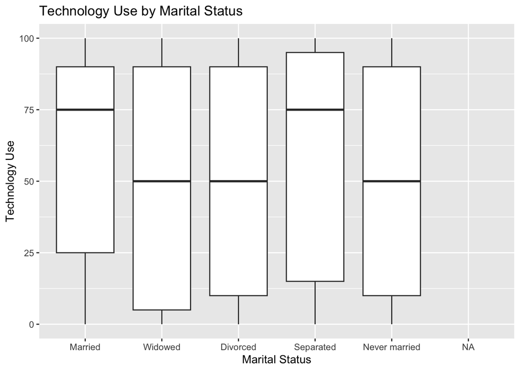

```r
# --------------------------------------------------
# Question 6
# Visualize technology use by marital status
# --------------------------------------------------

ggplot(data, aes(x = MARITAL, y = USETECH)) +
  geom_boxplot() +
  labs(
    title = "Technology Use by Marital Status",
    x = "Marital Status",
    y = "Technology Use"
  )
```

Interpretation: The boxplot allows comparison of medians and spread across groups.

```r
# --------------------------------------------------
# Question 7
# Calculate mean and standard deviation
# Drop NA values before calculation
# --------------------------------------------------

descriptives <- data %>%
  drop_na(USETECH, MARITAL) %>%
  group_by(MARITAL) %>%
  summarize(
    mean_use = mean(USETECH),
    sd_use = sd(USETECH)
  )

descriptives
```

```
## # A tibble: 5 × 3
##   MARITAL       mean_use sd_use
##   <fct>            <dbl>  <dbl>
## 1 Married           59.4   36.5
## 2 Widowed           48.9   39.5
## 3 Divorced          51.0   37.6
## 4 Separated         56.1   40.5
## 5 Never married     52.0   38.9
```

Interpretation: This shows average technology use and variability by marital group.

```r
# --------------------------------------------------
# Question 8
# Conduct one-way ANOVA
# Test whether technology use differs by marital status
# --------------------------------------------------

anova_data <- data %>%
  drop_na(USETECH, MARITAL)

anova_model <- aov(USETECH ~ MARITAL, data = anova_data)

summary(anova_model)
```

```
##               Df  Sum Sq Mean Sq F value  Pr(>F)
## MARITAL        4   21706    5426   3.822 0.00427 **
## Residuals   1404 1993352    1420
## ---
## Signif. codes:  0 '***' 0.001 '**' 0.01 '*' 0.05 '.' 0.1 ' ' 1
```

``Interpretation: If p < .05, there is a significant difference in technology use across marital groups.`

```r
# --------------------------------------------------
# Question 9
# Perform Tukey post-hoc test
# Identify which groups differ
# --------------------------------------------------

TukeyHSD(anova_model)
```

```
##   Tukey multiple comparisons of means
##     95% family-wise confidence level
##
## Fit: aov(formula = USETECH ~ MARITAL, data = anova_data)
##
## $MARITAL
##                               diff        lwr        upr     p adj
## Widowed-Married         -10.426738 -25.144120  4.2906452 0.2991642
## Divorced-Married         -8.345118 -16.101879 -0.5883579 0.0276735
## Separated-Married        -3.217932 -19.096500 12.6606347 0.9815161
## Never married-Married    -7.331726 -13.743243 -0.9202083 0.0156621
## Divorced-Widowed          2.081619 -13.514881 17.6781192 0.9962337
## Separated-Widowed         7.208805 -13.652939 28.0705494 0.8796954
## Never married-Widowed     3.095012 -11.877998 18.0680221 0.9801074
## Separated-Divorced        5.127186 -11.569471 21.8238428 0.9185202
## Never married-Divorced    1.013393  -7.218072  9.2448574 0.9972482
## Never married-Separated  -4.113793 -20.229580 12.0019934 0.9571210
```

Interpretation: Significant pairwise comparisons indicate which marital groups differ in technology use.

CH 8

```r
# --------------------------------------------------
# Question 1
# Load required packages and Chapter 8 dataset
# --------------------------------------------------

library(tidyverse)

data_ch8 <- read.csv("/Users/Lcc/water_educ_2015_who_unesco_ch8.csv")

str(data_ch8)
```

```
## 'data.frame':    97 obs. of  10 variables:
##  $ country            : chr  "Albania" "Antigua and Barbuda" "Argentina" "Australia" ...
##  $ med.age            : num  32.9 30.5 31.1 37.2 29.7 30.1 36.9 39.3 41.6 23 ...
##  $ perc.1dollar       : num  1 NA 1 NA 1 NA NA 1 NA NA ...
##  $ perc.basic2015sani : int  98 88 95 100 89 100 96 94 99 87 ...
##  $ perc.safe2015sani  : int  65 NA 26 74 NA 93 NA 76 97 NA ...
##  $ perc.basic2015water: int  91 97 100 100 84 100 98 98 100 97 ...
##  $ perc.safe2015water : int  69 NA NA NA 72 99 NA 94 98 NA ...
##  $ perc.in.school     : num  91.8 80.6 97.3 98.2 93.6 ...
##  $ female.in.school   : num  90.6 80.3 98.4 98.6 92.6 ...
##  $ male.in.school     : num  93 80.9 96.2 97.8 94.4 ...
```

```r
# --------------------------------------------------
# Question 2
# Select variables for analysis:
# male.in.school, female.in.school, perc.basic2015water
# --------------------------------------------------

data_ch8 <- data_ch8 %>%
  select(male.in.school, female.in.school, perc.basic2015water)

summary(data_ch8)
```

```
##  male.in.school  female.in.school perc.basic2015water
##  Min.   :38.66   Min.   :27.86    Min.   : 19.00
##  1st Qu.:82.68   1st Qu.:83.70    1st Qu.: 88.75
##  Median :91.50   Median :92.72    Median : 97.00
##  Mean   :87.00   Mean   :87.06    Mean   : 90.16
##  3rd Qu.:95.57   3rd Qu.:96.61    3rd Qu.:100.00
##  Max.   :99.36   Max.   :99.65    Max.   :100.00
##                                   NA's   :1
```

```r
# --------------------------------------------------
# Question 3
# Examine distribution of male.in.school
# --------------------------------------------------

summary(data_ch8$male.in.school)
```

```
##    Min. 1st Qu.  Median    Mean 3rd Qu.    Max.
##   38.66   82.68   91.50   87.00   95.57   99.36
```

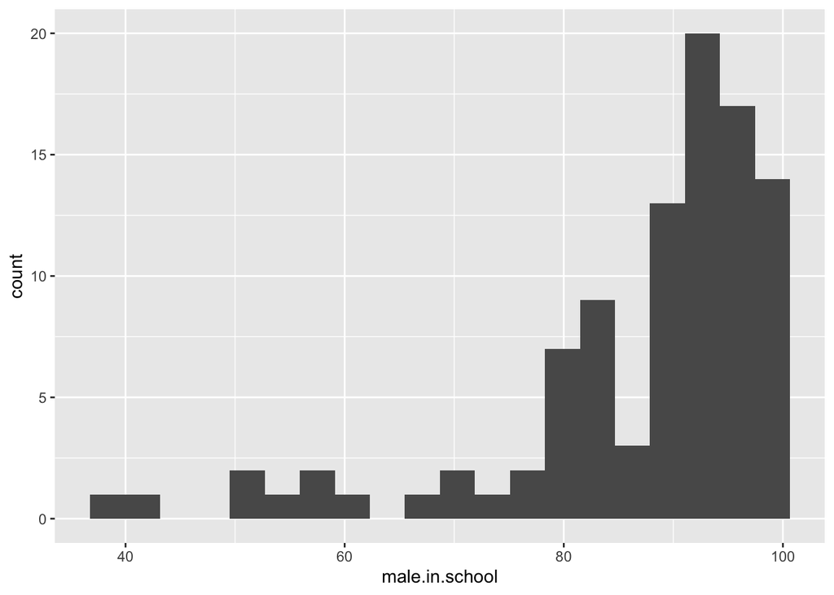

```r
ggplot(data_ch8, aes(x = male.in.school)) +
  geom_histogram(bins = 20)
```

Interpretation: This shows the distribution of male school enrollment across countries. The histogram allows us to examine skewness and overall spread.

```r
# --------------------------------------------------
# Question 4
# Examine distribution of female.in.school
# --------------------------------------------------

summary(data_ch8$female.in.school)
```

```
##    Min. 1st Qu.  Median    Mean 3rd Qu.    Max.
##   27.86   83.70   92.72   87.06   96.61   99.65
```

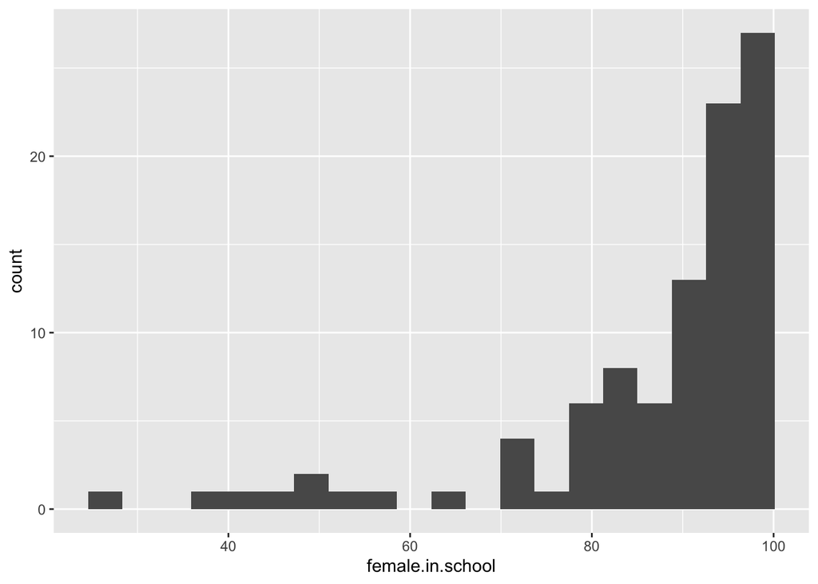

```r
ggplot(data_ch8, aes(x = female.in.school)) +
  geom_histogram(bins = 20)
```

Interpretation: This shows how female school enrollment is distributed across countries and whether the variable appears normally distributed.

```r
# --------------------------------------------------
# Question 5
# Examine distribution of perc.basic2015water
# --------------------------------------------------

summary(data_ch8$perc.basic2015water)
```

```
##    Min. 1st Qu.  Median    Mean 3rd Qu.    Max.    NA's
##   19.00   88.75   97.00   90.16  100.00  100.00       1
```

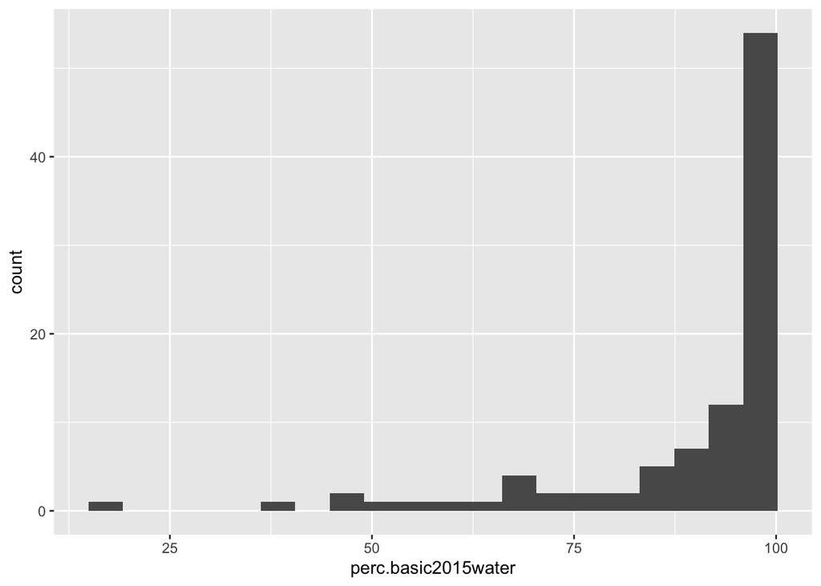

```r
ggplot(data_ch8, aes(x = perc.basic2015water)) +
  geom_histogram(bins = 20)
```

Interpretation: This histogram shows the distribution of access to basic water services across countries.

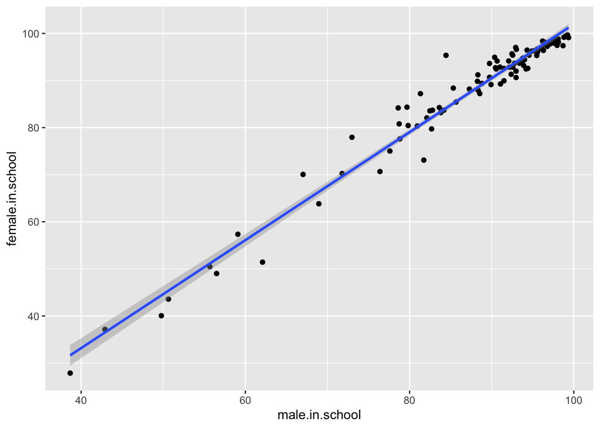

```r
# --------------------------------------------------
# Question 8 (Assumption Check)
# Scatterplot: male.in.school vs female.in.school
# --------------------------------------------------

ggplot(data_ch8, aes(x = male.in.school, y = female.in.school)) +
  geom_point() +
  geom_smooth(method = "lm")
```

Interpretation: The scatterplot allows us to assess linearity. If the relationship appears roughly linear, regression assumptions may be met.

```r
# --------------------------------------------------
# Question 6
# Linear regression: female.in.school ~ male.in.school
# --------------------------------------------------

model1 <- lm(female.in.school ~ male.in.school, data = data_ch8)

summary(model1)
```

```
##
## Call:
## lm(formula = female.in.school ~ male.in.school, data = data_ch8)
##
## Residuals:
##     Min      1Q  Median      3Q     Max
## -7.9200 -1.4361 -0.3326  1.1921 11.2307
##
## Coefficients:
##                 Estimate Std. Error t value Pr(>|t|)
## (Intercept)    -12.67820    1.93287  -6.559 2.82e-09 ***
## male.in.school   1.14634    0.02198  52.161  < 2e-16 ***
## ---
## Signif. codes:  0 '***' 0.001 '**' 0.01 '*' 0.05 '.' 0.1 ' ' 1
##
## Residual standard error: 2.788 on 95 degrees of freedom
## Multiple R-squared:  0.9663, Adjusted R-squared:  0.9659
## F-statistic:  2721 on 1 and 95 DF,  p-value: < 2.2e-16
```

Interpretation: If p < 0.05, male enrollment significantly predicts female enrollment. The R-squared indicates how much variation in female enrollment is explained by male enrollment.

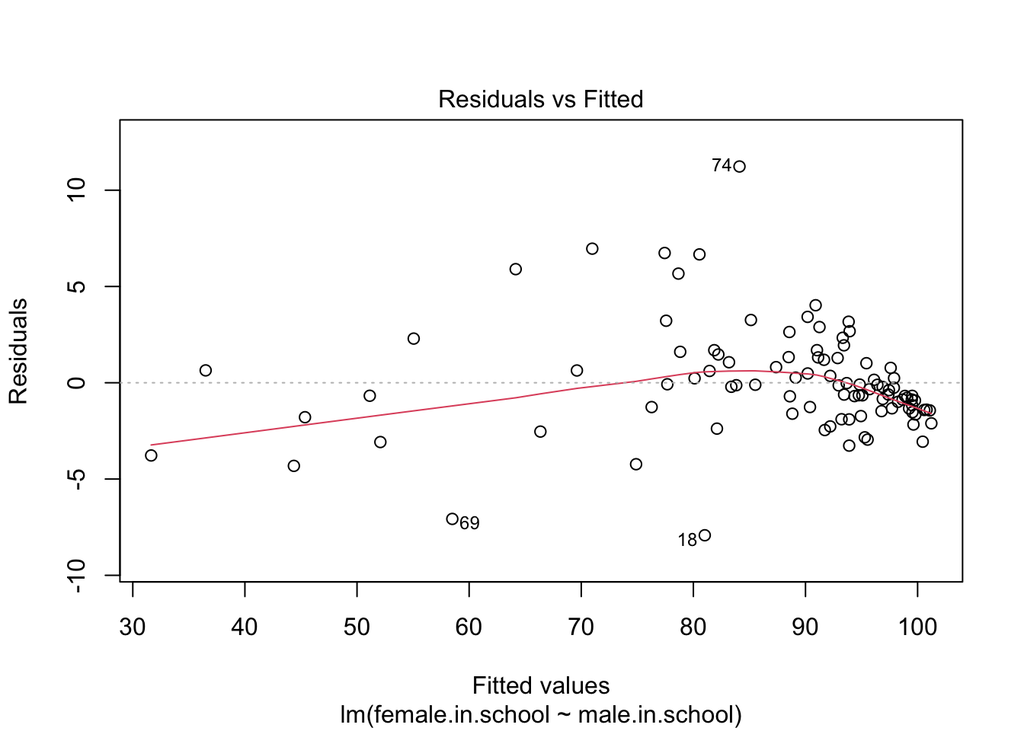

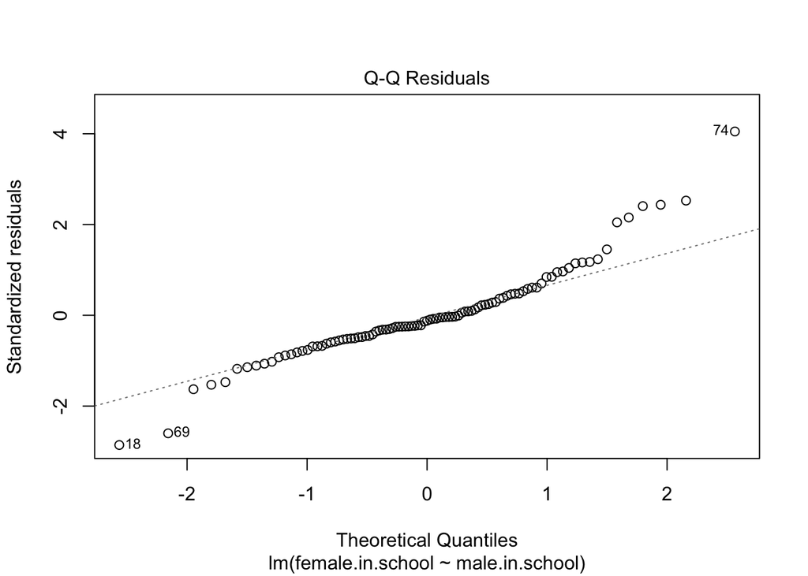

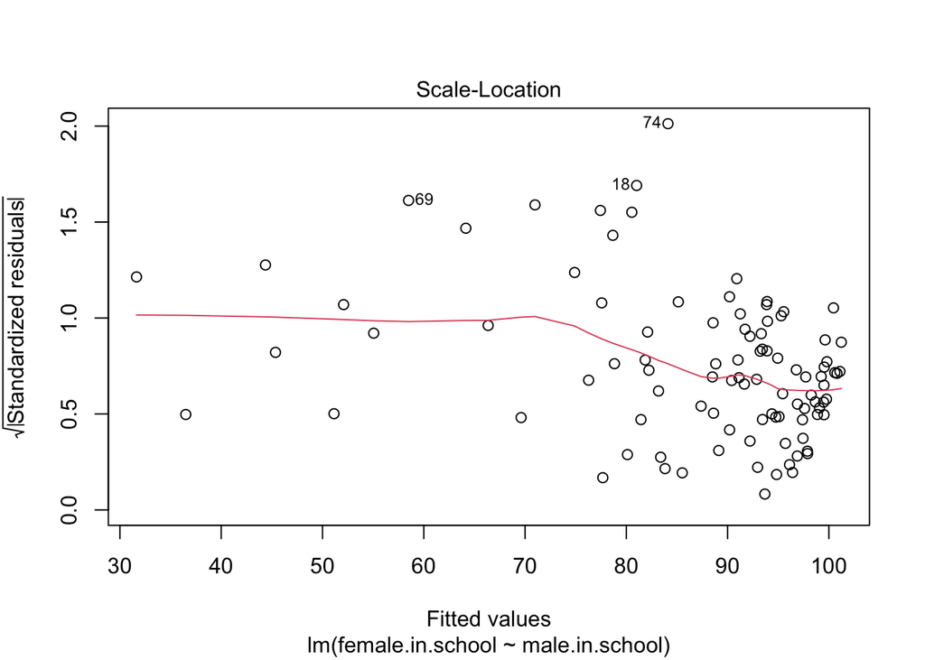

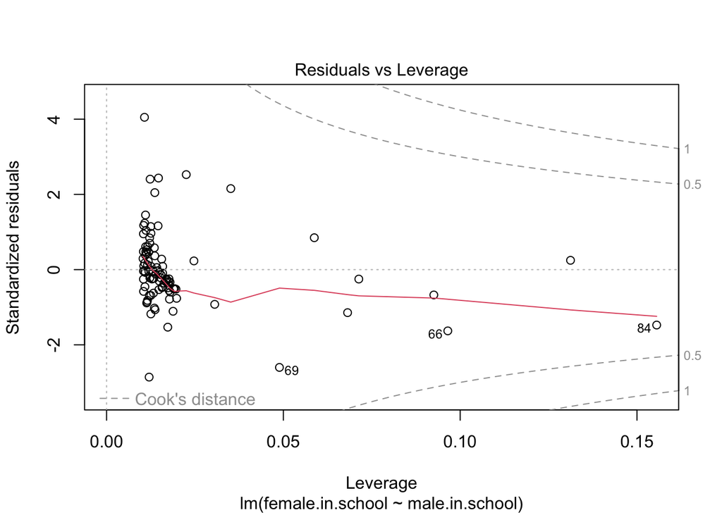

```r
# --------------------------------------------------
# Residual diagnostics
# --------------------------------------------------

plot(model1)
```

Interpretation: Residual plots help assess normality and homoscedasticity. If assumptions are reasonably satisfied, linear regression is appropriate.

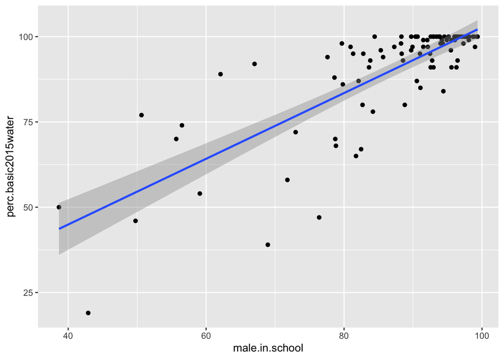

```r
# --------------------------------------------------
# Question 8 (Assumption Check for second pair)
# Scatterplot: male.in.school vs perc.basic2015water
# --------------------------------------------------

ggplot(data_ch8, aes(x = male.in.school, y = perc.basic2015water)) +
  geom_point() +
  geom_smooth(method = "lm")
```

Interpretation: This plot helps assess whether access to water is linearly related to male school enrollment.

```r
# --------------------------------------------------
# Question 6
# Linear regression: perc.basic2015water ~ male.in.school
# --------------------------------------------------

model2 <- lm(perc.basic2015water ~ male.in.school, data = data_ch8)

summary(model2)
```

```
##
## Call:
## lm(formula = perc.basic2015water ~ male.in.school, data = data_ch8)
##
## Residuals:
##     Min      1Q  Median      3Q     Max
## -33.814  -2.483   0.990   4.432  22.791
##
## Coefficients:
##                Estimate Std. Error t value Pr(>|t|)
## (Intercept)     6.38897    6.73468   0.949    0.345
## male.in.school  0.96344    0.07662  12.575   <2e-16 ***
## ---
## Signif. codes:  0 '***' 0.001 '**' 0.01 '*' 0.05 '.' 0.1 ' ' 1
##
## Residual standard error: 9.709 on 94 degrees of freedom
##   (1 observation deleted due to missingness)
## Multiple R-squared:  0.6272, Adjusted R-squared:  0.6232
## F-statistic: 158.1 on 1 and 94 DF,  p-value: < 2.2e-16
```

Interpretation: If p < 0.05, male school enrollment significantly predicts access to water. The strength of association is indicated by R-squared.

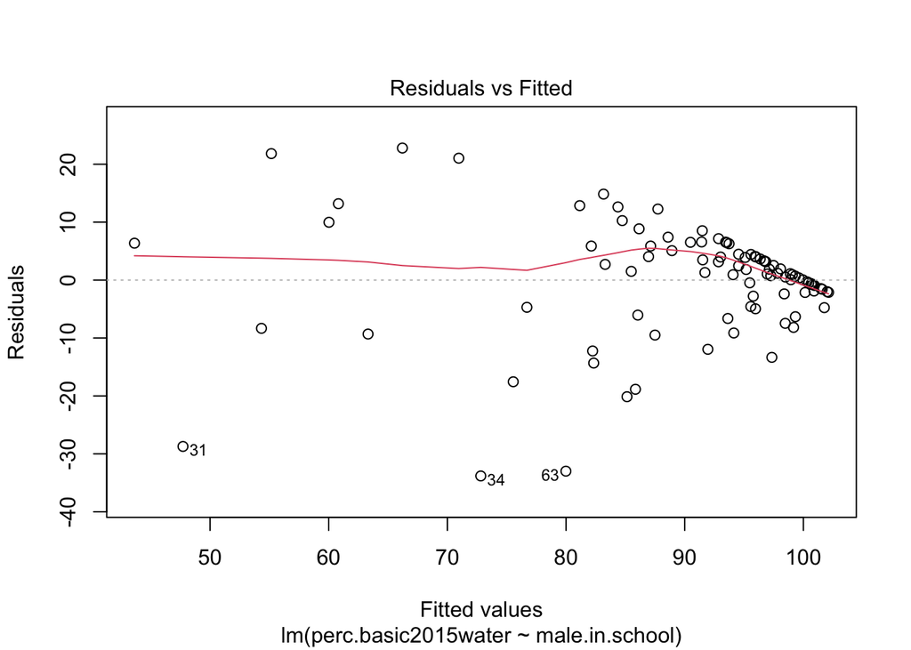

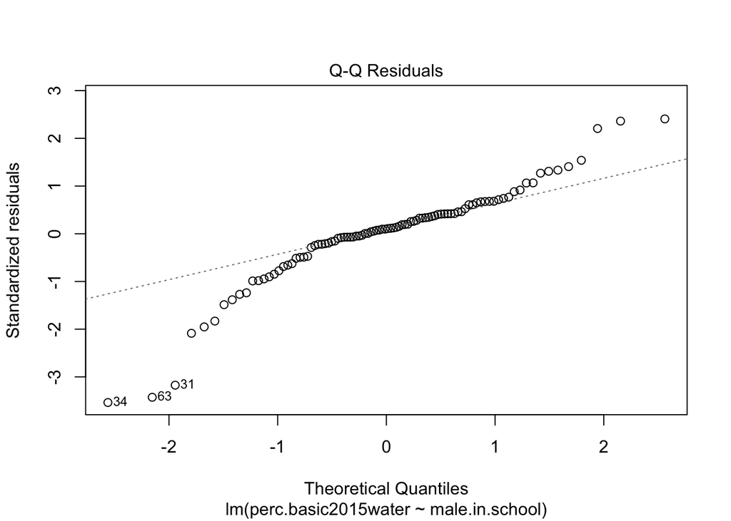

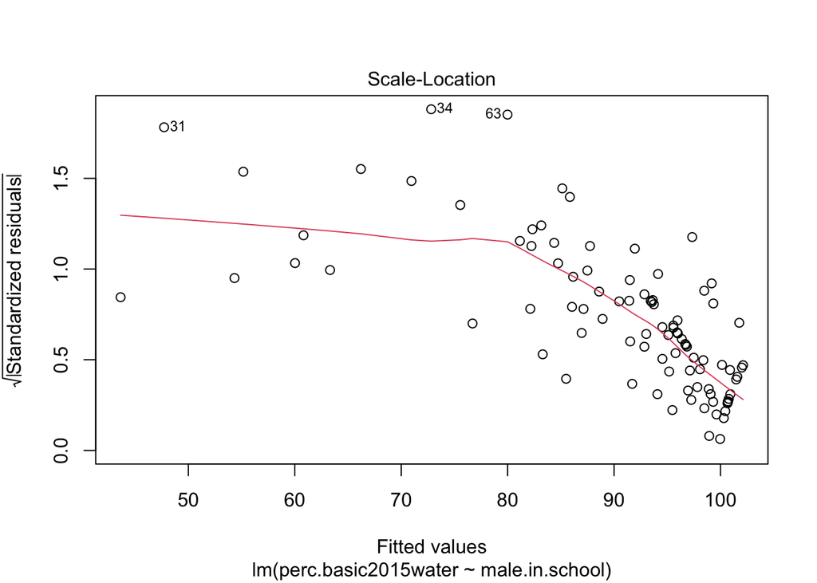

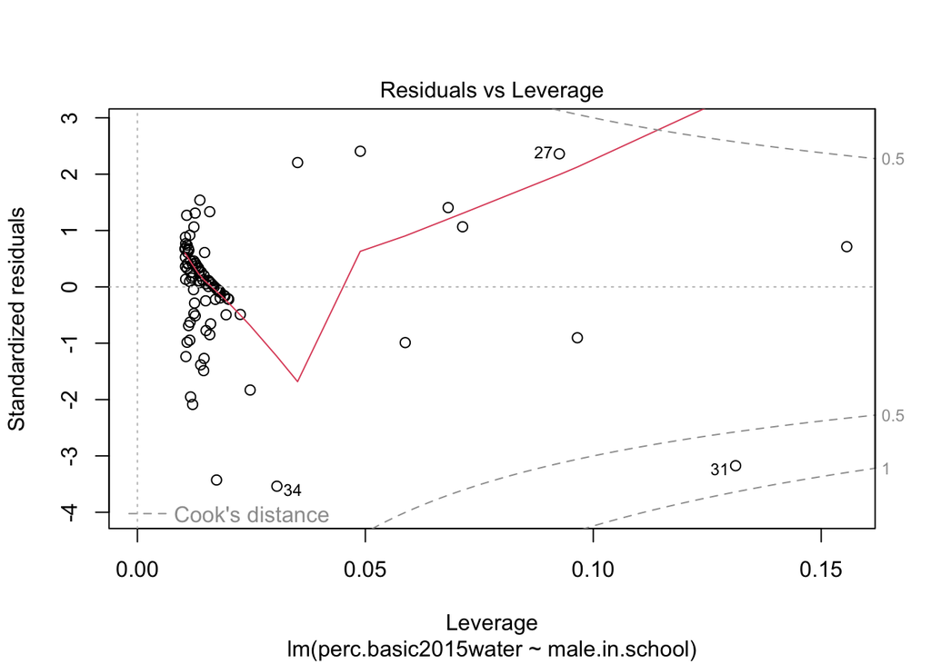

```r
# --------------------------------------------------
# Residual diagnostics
# --------------------------------------------------

plot(model2)
```

Interpretation: If residuals appear randomly distributed, regression assumptions are reasonably met. If not, a nonparametric approach (Spearman correlation) may be more appropriate.

```r
# --------------------------------------------------
# Question 9
# Nonparametric alternative (Spearman correlation)
# --------------------------------------------------

cor.test(data_ch8$male.in.school,
         data_ch8$female.in.school,
         method = "spearman")
```

```
##
##  Spearman's rank correlation rho
##
## data:  data_ch8$male.in.school and data_ch8$female.in.school
## S = 6442, p-value < 2.2e-16
## alternative hypothesis: true rho is not equal to 0
## sample estimates:
##       rho
## 0.9576452
```

```r
cor.test(data_ch8$male.in.school,
         data_ch8$perc.basic2015water,
         method = "spearman")
```

```
##
##  Spearman's rank correlation rho
##
## data:  data_ch8$male.in.school and data_ch8$perc.basic2015water
## S = 40160, p-value < 2.2e-16
## alternative hypothesis: true rho is not equal to 0
## sample estimates:
##       rho
## 0.7276206
```

Interpretation: If assumptions are violated, Spearman correlation evaluates monotonic relationships without requiring normality.